# Matrix algebra session

Authored by Stevan J Arnold, w/additions from Josef Uyeda, Evelyn Metzger, & Patrick Phillips)

Let’s start with the addition of two vectors. Run the text that follows into the R console a line at a time, hit Enter, and examine the response. The first and third statements define the two vectors Notice that R treats vectors as 1 column or 1 row matrices

```r
a=matrix(data=c(2,3),nrow=2,ncol=1)
a
##      [,1]
## [1,]    2
## [2,]    3
```

```r
e=matrix(data=c(3,4),nrow=2,ncol=1)
e
##      [,1]
## [1,]    3
## [2,]    4
```

```r
z=a+e
z
##      [,1]
## [1,]    5
## [2,]    7
```

Now let’s try matrix addition. We begin by defining the two matrices that we will add.

```r
G=matrix(data=c(2,3,3,8),nrow=2,ncol=2)
G
##      [,1] [,2]
## [1,]    2    3
## [2,]    3    8
```

```r
E=matrix(data=c(1,2,2,5),nrow=2,ncol=2)
E
##      [,1] [,2]
## [1,]    1    2
## [2,]    2    5
```

```r
P=G+E
P
##      [,1] [,2]
## [1,]    3    5
## [2,]    5   13
```

Next, let’s multiply a matrix by a vector. The following exercise computes the response to directional selection on two traits, given the G-matrix and a vector of selection gradients.

```r
G
##      [,1] [,2]
## [1,]    2    3
## [2,]    3    8
```

```r
beta=matrix(data=c(0.2,0.4),nrow=2,ncol=1)
beta
##      [,1]
## [1,]  0.2
## [2,]  0.4
```

```r
deltazbar=G %*% beta
deltazbar
##      [,1]
## [1,]  1.6
## [2,]  3.8
```

Note that to properly execute matrix multiplication, we have to use $%*%$ rather thatn $*$. This is because $*$ will simply conduct element-wise multiplication, whereas matrix multiplication is rows $\times$ columns. So the above is equivalent to:

```r
G[1,1] * beta[1,1] + G[1,2] * beta[2,1] #The first index number is the row, the second number is the column
## [1] 1.6
```

```r
G[2,1] * beta[1,1] + G[2,2] * beta[2,1]
## [1] 3.8
```

```r
cat("\n\n")
```

```r
#or equivalently
sum(G[1,] * beta[,1])
## [1] 1.6
```

```r
sum(G[2,] * beta[,1])
## [1] 3.8
```

Now, the multiplication of two matrices. Here we depart from the sequence in Arnold’s 1994 Appendix. We will compute the inverse of a matrix and see if the product of a matrix and its inverse yields the identity matrix. This is the matrix equivalent of multiplying $x \times \frac{1}{x} = 1$.

```r
Ginverse=solve(G) #G^(-1)
Ginverse
##            [,1]       [,2]
## [1,]  1.1428571 -0.4285714
## [2,] -0.4285714  0.2857143
```

```r
G %*% Ginverse #probably won't be exactly the identity matrix due to floating point/numerical issues in computation!
##               [,1]         [,2]
## [1,]  1.000000e+00 1.110223e-16
## [2,] -4.440892e-16 1.000000e+00
```

Another useful matrix operation is its transpose. Here we perform the matrix algebra equivalent of $\sqrt{x} * \sqrt{x} = x$

```r
chol(G) #Cholesky decomposition of G
##          [,1]     [,2]
## [1,] 1.414214 2.121320
## [2,] 0.000000 1.870829
```

```r
t(chol(G)) #Transpose of the same matrix
##          [,1]     [,2]
## [1,] 1.414214 0.000000
## [2,] 2.121320 1.870829
```

```r
diag(2) #Identity matrix
##      [,1] [,2]
## [1,]    1    0
## [2,]    0    1
```

```r
G #original G
##      [,1] [,2]
## [1,]    2    3
## [2,]    3    8
```

```r
t(chol(G))%*% diag(2)%*%(chol(G)) #Reconstitute G
##      [,1] [,2]
## [1,]    2    3
## [2,]    3    8
```

Finally, let’s solve for the eigenvalues and eigenvectors of the G-matrix.  
What does the output mean?

```r
eigen(G)
## eigen() decomposition
## $values
## [1] 9.2426407 0.7573593
##
## $vectors
##           [,1]       [,2]
## [1,] 0.3826834 -0.9238795
## [2,] 0.9238795  0.3826834
```

To find out what the output means, let’s write some script that will take a sample using a bivariate G matrix, then plot the 95% confidence ellipse for that sample, and the eigenvectors of our G matrix

First, we define our matrix and take a look at it

```r
G=matrix(data=c(1,0.8,0.8,1),nrow=2, ncol=2,byrow=TRUE)
G
##      [,1] [,2]
## [1,]  1.0  0.8
## [2,]  0.8  1.0
```

Second, we load two libraries that we’ll need to call

```r
library(MASS)
library(car)
```

```r
data <- mvrnorm(1000, mu = c(0,0), Sigma=G)
head(data)
##           [,1]        [,2]
## [1,] 0.2852600 -0.03331573
## [2,] 1.2653582  1.12256434
## [3,] 0.1420852 -0.07501431
## [4,] 0.2382426 -0.43084002
## [5,] 0.9312722  1.23316445
## [6,] 0.5102096  0.15473690
```

Fourth, we plot our data

```r
x.range = c(-3.5,3.5)
y.range = c(-3.5,3.5)
```

Fifth, we plot the 95% confidence ellipse in green

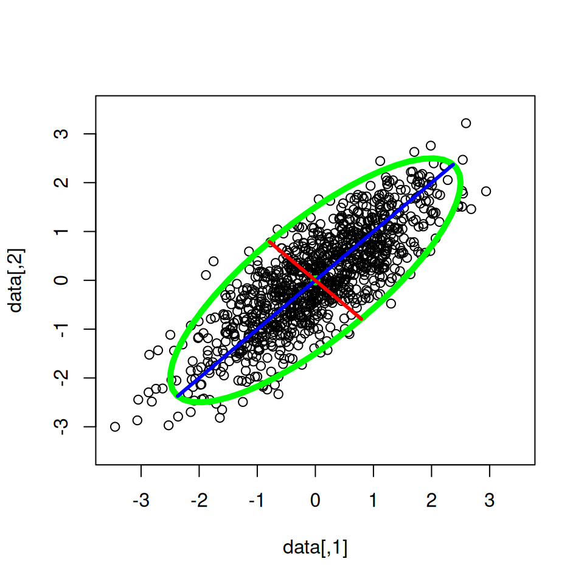

```r
plot(data, xlim=x.range, ylim=y.range)
null.bar=c(0,0)
ellipse(center=null.bar, shape=G, radius=2.5, center.cex=1, lwd=5, col="green", add=TRUE)

# Plot the first eigenvector in blue. This is a game of "connect the dots"
n=sqrt(eigen(G)$values[1])  * 2.5 #Sqrt of the 2nd eigenvalue (i.e. standard deviation) multiplied by 2.5 to get 95% CI
delx1 = null.bar[1]  + n*eigen(G)$vectors[1,1]
delx2 = null.bar[2]  + n*eigen(G)$vectors[2,1]
delx11 = null.bar[1]  - n*eigen(G)$vectors[1,1]
delx22 = null.bar[2]  - n*eigen(G)$vectors[2,1]
x.values=c(null.bar[1] , delx1, delx11)
y.values=c(null.bar[2] , delx2, delx22)
lines(x.values, y.values, lwd=3, col="blue")


#Finally, let’s  plot the second eigenvector in red

m=sqrt(eigen(G)$values[2]) * 2.5 #Sqrt of the 2nd eigenvalue (i.e. standard deviation) multiplied by 2.5 to get 95% CI
delx1 = null.bar[1] + m*eigen(G)$vectors[1,2]
delx2 = null.bar[2] + m*eigen(G)$vectors[2,2]
delx11 =  null.bar[1] - m*eigen(G)$vectors[1,2]
delx22 =  null.bar[2]  - m*eigen(G)$vectors[2,2]
x.values=c(null.bar[1], delx1, delx11)
y.values=c(null.bar[2] , delx2, delx22)
lines(x.values, y.values, lwd=3, col="red")
```

Now try changing the G matrix and see how the eigenvectors are affected

Here is the code you can use plot a 3 dimensional G-matrix in the package `rgl`. We are not running it by defaul (`eval=FALSE`) because `rgl` can sometimes be tricky to install.

```r
library(rgl)
G=matrix(data=c(1,0.9,0.8,0.9,1,0.8,0.8,0.8,1),nrow=3, ncol=3,byrow=TRUE)
G
data <- mvrnorm(1000, mu = c(0,0,0), Sigma=G)
plot3d(data)
```